# On studying the patterns of individual-based tree mortality in natural forests: A modelling analysis - ScienceDirect

## Outline

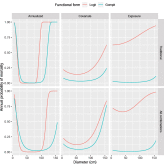

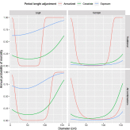

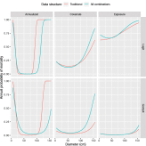

## [Forest Ecology and Management](https://www.sciencedirect.com/science/journal/03781127)

[Volume 475](https://www.sciencedirect.com/science/journal/03781127/475/supp/C), 1 November 2020, 118369

# On studying the patterns of individual-based tree mortality in natural forests: A modelling analysis

[ChristianSalas-Eljatib<sup>a</sup><sup>b</sup>](https://www.sciencedirect.com/science/article/abs/pii/S0378112720311385?dgcid=rss_sd_all#!)[Aaron R.Weiskittel<sup>c</sup>](https://www.sciencedirect.com/author/13806825800/aaron-weiskittel)

## Highlights

**•**

Inference and robustness of mortality predictions strongly rely on modelling strategy.

**•**

Using all possible combinations of observations in data is better for covariate testing.

**•**

Considering the period length as a model exposure term was best for accounting of time.

**•**

Multi-level Gompit binomial model shown best and most robust for modelling tree-level mortality.

## Abstract

Tree mortality is a critical ecological phenomenon shaping forest ecosystem dynamics, structure, and composition, while its effects are of global relevance due to its relationship with forest conditions and environmental changes. There are several challenges associated with individual-based mortality data, particularly observations with uneven measurement intervals. Here, we develop and examine several common individual-based mortality modelling strategies that simultaneously account for unequal measurement lengths and the hierarchical structure of the data in long-term, permanent plot data from the mixed *Nothofagus* forests in south-central Chile. These strategies depend on: (a) the functional model form (logit and Gompit), (b) the period length adjustment method (annualized, covariate, and exposure), and (c) the data structure used (traditional or all multiple combinations of the time series). Our findings indicated that the Gompit functional form outperformed the commonly used logit link function. Furthermore, considering the period length as exposure in a generalized linear mixed-effects model offered better goodness-of-fit than the other examined period length adjustments. Using all the possible combinations of the dynamic data did not improve the prediction capabilities of the model variants, but important differences were found in the statistical inferences of the fitted models. Our results highlighted that understanding tree mortality strongly relies on using a suitable modelling strategy that is capable of both capturing and assigning the sources of variation to the corresponding variables, which was best accomplished using a multi-level, binary, and Gompit-exposure modelling framework in this analysis.

## Keywords

Competition

Survival

Forest dynamics

Logistic regression

*Nothofagus*

Temperate forest

Gompit

Logit

Multi-level, mixed-effects model

© 2020 Elsevier B.V. All rights reserved.